# Final Project: Boarding School Clusters in New Hampshire

Author

Dorothy Wongkarnta

Published

May 26, 2026

## Background

This project examines the spatial and socioeconomic characteristics of neighborhoods surrounding boarding schools in New Hampshire, using census block group data as the primary unit of analysis. Neighborhoods are defined as all block groups within a 3-mile radius of each boarding school. The study investigates how proximity to these schools relates to local economic conditions and broader community characteristics. It also uses distance-based measures to explore whether spatial relationships can help explain variation in socioeconomic outcomes.

#### **Research questions:**

1. What are the spatial and socioeconomic neighborhood characteristics surrounding boarding schools in New Hampshire?
2. Can we predict median household income based on distance to the nearest boarding school?

By combining spatial analysis with predictive modeling, the project evaluates whether being within 3 miles of a boarding school is associated with differences in income across surrounding block groups.

## Data Collection

This project uses census block group–level data to analyze neighborhoods surrounding boarding schools in New Hampshire. Neighborhoods are defined as all block groups within a 3-mile radius of each boarding school. The dataset combines spatial and socioeconomic information to capture both geographic proximity and local economic conditions.

1. Private school location data which can be downloaded from https://catalog.data.gov/dataset/private-school-locations-current This dataset provides geocoded records of private schools across the United States, including school names, physical addresses, latitude and longitude coordinates, and school characteristics such as type and level. It is derived from the U.S. Department of Education’s private school data (NCES-based reporting).
2. The list of boarding schools in New Hamshire is from https://en.wikipedia.org/wiki/Category:Boarding_schools_in_New_Hampshire
3. Census block group–level socioeconomic data is used to characterize neighborhood conditions around boarding schools in New Hampshire. The dataset is drawn from the U.S. Census Bureau’s American Community Survey (ACS). In this project, we will focus on
   - median household income (B19013_001)
   - total population (B01003_001)
   - educational attainment measures for the population aged 25 and older (B15003_001 through B15003_025), including counts of bachelor’s, master’s, professional, and doctorate degrees
   - median home value (B25077_001)
   - unemployment and labor force statistics (B23025_003 and B23025_005)
4. Geographic boundary data for New Hampshire is obtained using the tigris package.

```r
# Load libraries
library(htmlwidgets)
library(tidyr)
library(tidycensus)
library(readr)
library(dplyr)
library(tigris)
library(tibble)
library(gt)
library(sf)
library(leaflet)
library(knitr)
library(lubridate)
library(ggplot2)
library(stringr)
library(units)
library(spdep)

# Print numbers normally (avoid scientific notation)
options(scipen = 999)
```

## Boarding School in NH Data

Since the dataset includes all private schools in the United States, we performed data cleaning and processing by

1) Standardized text data by removing extra spaces, replacing special characters, and converting all values to uppercase

2) Filtered the dataset to include only private schools located in New Hampshire

The map below shows all private schools within the New Hampshire boundary.

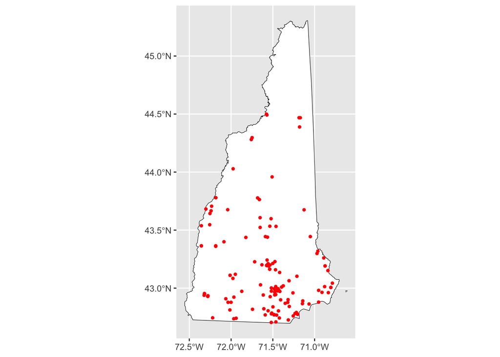

```r
# Import Private School data
private_school <- st_read("private_school_location.geojson")

#Standardize data
private_school <- private_school %>%
  mutate(
    NAME_clean = NAME %>%
      str_to_upper() %>%
      str_replace_all("\\s+", " ") %>%
      str_trim()
  )

# Filter for New Hampshire
nh_private <- private_school %>%
  filter(STATE == 'NH')

# Download tigris boundary
nh_boundary <- tigris::states(cb = TRUE) |>
  dplyr::filter(NAME == "New Hampshire")

# Quick visual of Private in NH
ggplot() +
  geom_sf(data = nh_boundary, fill = "white", color = "black") +
  geom_sf(data = nh_private, color = "red", size = 1)
```

To identify only boarding schools, we first filtered the list of private schools using the Wikipedia list of boarding schools in New Hampshire as a reference. We then removed duplicate records based on school names and geographic location to ensure each institution was uniquely represented. This process resulted in a smaller set of boarding schools within the New Hampshire boundary.

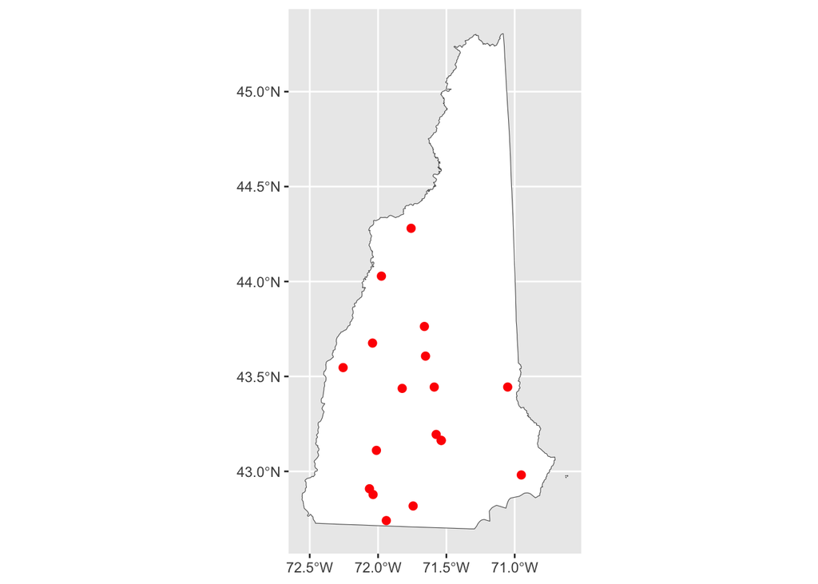

```r
# Keep only Boarding Schools
nh_boarding <- nh_private %>%
  filter(
    str_detect(NAME_clean,
               "BREWSTER|KIMBALL|ROBINSON|CARDIGAN|MEETING|CATHERINE|ST PAUL|SHORTRIDGE|DUBLIN|NEW HAMPTON|TILTON|TILDEN|HOLDERNESS|HAMPSHIRE|MOWING|OLIVERIAN|PROCTOR|NEW HAMPTON|EXETER|WHITE MOUNTAIN|WEDIKO")
  )

# Remove Duplicates
nh_boarding <- nh_boarding %>%
  distinct(NAME_clean, geometry, .keep_all = TRUE)

# Quick visual for Boarding in NH
ggplot() +
  geom_sf(data = nh_boundary, fill = "white") +
  geom_sf(data = nh_boarding, color = "red", size = 2)
```

## Census Tract Data

We use socioeconomic data to better understand the neighborhoods surrounding boarding schools in New Hampshire by downloading ACS 5-year estimates for New Hampshire block groups using the tidycensus package, including variables related to population, income, education, unemployment, and housing value. The data is then reshaped so that each block group has one row with all variables.

We further create additional measures such as the share of residents with a bachelor’s degree or higher and and unemployment rate. Finally, we compute spatial connectivity between block groups to keep only block groups with at least one neighboring unit for spatial consistency in the analysis.

```r
# Download block-group data from ACS
options(tigris_use_cache = TRUE)

block_data <- get_acs(
  geography = "block group",
  state = "NH",
  survey = "acs5",
  year = 2024,
  geometry = TRUE,
  variables = c(
    median_income = "B19013_001",
    total_pop = "B01003_001",
    total_25plus = "B15003_001",
    bachelors = "B15003_022",
    masters = "B15003_023",
    professional = "B15003_024",
    doctorate = "B15003_025",
    median_home_value = "B25077_001",
    unemployment = "B23025_005",
    labor_force = "B23025_003"
  ),
  progress_bar = FALSE
)

# Reshape to one row per each block
block_data <- block_data %>%
  select(GEOID, variable, estimate, geometry) %>%
  pivot_wider(names_from = variable, values_from = estimate)

block_data <- block_data %>%
  mutate(
    # % of At Least Bachelor's
    bachelors_or_higher_pct =
      (bachelors + masters + professional + doctorate) /
      total_25plus,

    # Unemployment Rate
    unemployment_rate =
      unemployment / labor_force
  )

# Only keep tracts that have attached tracts
block_data <- block_data %>%
  mutate(n_neighbors = lengths(st_intersects(block_data, block_data))) %>%
  filter(n_neighbors > 1)
```

## Creating Buffer around each Boarding School

In this project, neighborhood around boarding schools is defined as a 3-mile radius around each school. To properly measure distances and create spatial buffers, we use 6525 as an appropriate projected coordinate reference system (CRS) for New Hampshire based on suggest_crs.

Next, a 3-mile buffer is created around each boarding school after converting miles into feet. Census block group data is also transformed into the same CRS so that spatial operations between datasets are consistent. Finally, the New Hampshire boundary, boarding school locations, and their buffers are plotted together to visually show the 3-mile neighborhoods surrounding each school.

```r
# Suggest an appropriate CRS for distance calculations
crsuggest::suggest_crs(nh_boarding)
```

```
# A tibble: 10 × 6
   crs_code crs_name                        crs_type crs_gcs crs_units crs_proj4
   <chr>    <chr>                           <chr>      <dbl> <chr>     <chr>
 1 6525     NAD83(2011) / New Hampshire (f… project…    6318 us-ft     +proj=tm…
 2 6524     NAD83(2011) / New Hampshire     project…    6318 m         +proj=tm…
 3 3614     NAD83(NSRS2007) / New Hampshir… project…    4759 us-ft     +proj=tm…
 4 3613     NAD83(NSRS2007) / New Hampshire project…    4759 m         +proj=tm…
 5 3445     NAD83(HARN) / New Hampshire (f… project…    4152 us-ft     +proj=tm…
 6 3437     NAD83 / New Hampshire (ftUS)    project…    4269 us-ft     +proj=tm…
 7 32110    NAD83 / New Hampshire           project…    4269 m         +proj=tm…
 8 32010    NAD27 / New Hampshire           project…    4267 us-ft     +proj=tm…
 9 2823     NAD83(HARN) / New Hampshire     project…    4152 m         +proj=tm…
10 3749     NAD83(HARN) / UTM zone 19N      project…    4152 m         +proj=ut…
```

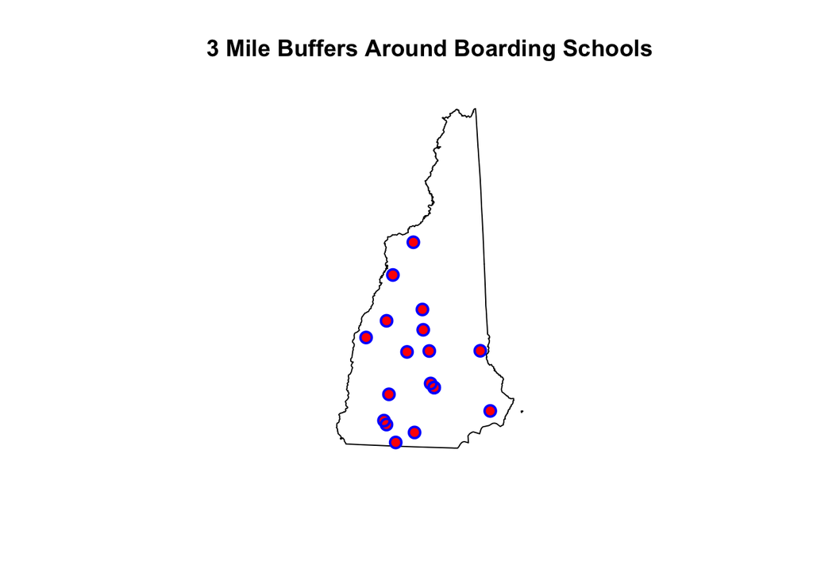

```r
# Reproject boarding school's points to NAD83(2011) / New Hampshire (ftUS)
nh_boarding_projected <- nh_boarding %>%
  st_transform(st_crs(6525))

#use units for conversion ( 3miles ~ 5 km)
three_mile_feet <- set_units(3, "miles") %>%
  set_units("feet")

# Create the buffer
nh_boarding_buffer <- nh_boarding_projected %>%
  st_buffer(dist = three_mile_feet)

# Put on same CRS
block_data <- block_data %>%
  st_transform(st_crs(nh_boarding_buffer))

# Plot the buffer on top of the NH outline
# (Transform NH boundaries to the same CRS as the buffer)
nh_boundary_6525 <- nh_boundary %>%
  st_transform(st_crs(nh_boarding_buffer))

plot(st_geometry(nh_boundary_6525), col = NA, border = "black", main = "3 Mile Buffers Around Boarding Schools")
plot(st_geometry(nh_boarding_projected), add = TRUE, pch = 19, col = "red")
plot(st_geometry(nh_boarding_buffer), add = TRUE, border = "blue", lwd = 2)
```

## Choropleth Maps with Boarding School Buffers

With the 3-mile buffer around the boarding schools, I created choropleth maps of each variable in QGIS to better understand the spatial distribution of the variables across blocks. The maps also highlight blocks located within the buffer areas. We can see that the choropleth maps of median household income and median home value are very similar with the higher price and income on the southeastern region closet to Boston while the percent of individuals with at least bachelor’s degree and unemployment are scattered in value.

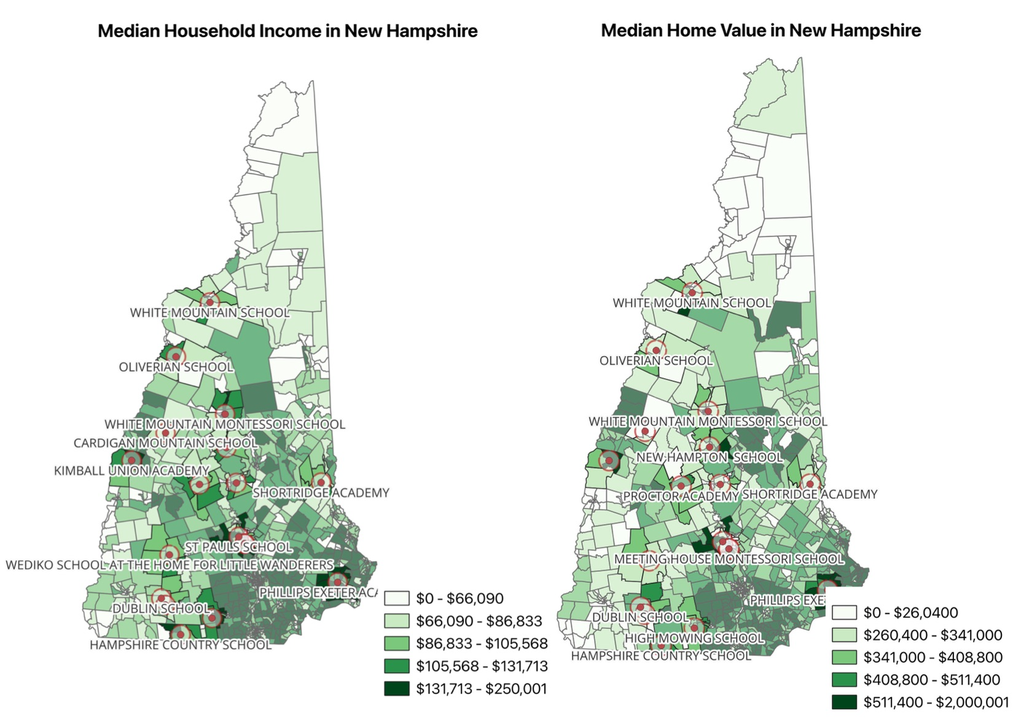

```r
knitr::include_graphics('median_income_home2.png')
```

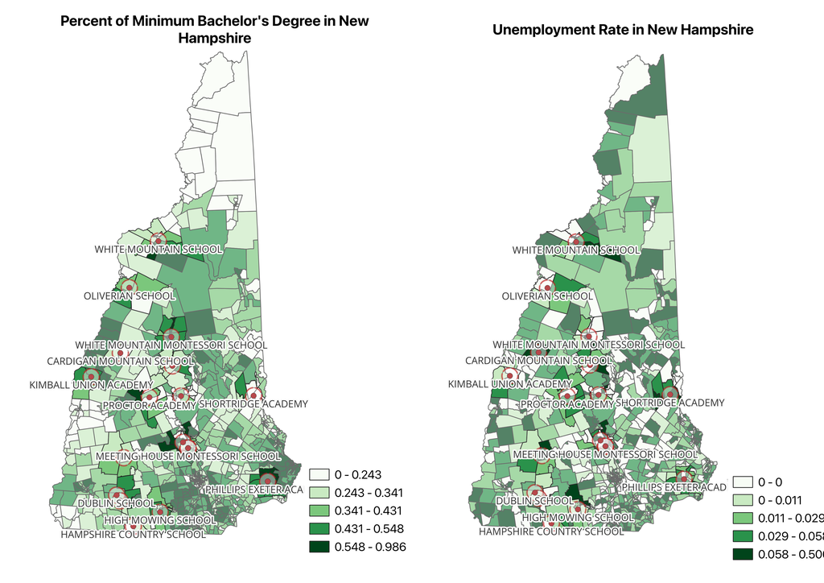

```r
knitr::include_graphics('bachelor_unemployment.png')
```

## Summary Tables of Neighborhood within and outside of Buffer

To answer our first research question, we first examine summary statistics comparing block groups located within 3 miles of boarding schools to those outside this range. A binary indicator is created using spatial intersections to classify each census block group are within 3 miles buffer of the school. We then group the data by this indicator and calculate average socioeconomic characteristics, including income, home value, educational attainment, and unemployment rates.

```r
# Are they within 3 miles?
block_data$within_3_miles <- lengths(
  st_intersects(block_data, nh_boarding_buffer)
) > 0

block_buffer_spatial_join <- st_join(
  block_data,
  nh_boarding_buffer,
  join = st_intersects,
  left = FALSE
)

# Keep only tracts that joined to a buffer
block_within_boarding_buffer <- block_buffer_spatial_join %>%
  filter(!is.na(NAME_clean))

# Summarize tract characteristics inside the Boarding School's buffers
# tract_characteristics_around_nh_boarding_buffer <- block_within_boarding_buffer %>%
#   st_drop_geometry() %>%
#   summarise(
#     average_median_hh_income = mean(median_income, na.rm = TRUE),
#     average_population = mean(total_pop, na.rm = TRUE),
#     average_median_home_value = mean(median_home_value, na.rm = TRUE),
#     average_pct_bachelors_or_higher = mean(bachelors_or_higher_pct, na.rm = TRUE),
#     average_pct_unemployment = mean(unemployment_rate, na.rm = TRUE),
# )

tract_characteristics_gt <- block_data %>%
  st_drop_geometry() %>%
  group_by(within_3_miles) %>%
  summarise(
    average_median_hh_income = mean(median_income, na.rm = TRUE),
    average_median_home_value = mean(median_home_value, na.rm = TRUE),
    average_pct_bachelors_or_higher = mean(bachelors_or_higher_pct, na.rm = TRUE),
    average_pct_unemployment = mean(unemployment_rate, na.rm = TRUE),
    .groups = "drop"
  ) %>%
  gt() %>%
  tab_header(
    title = "Block Group Characteristics Within vs Outside 3 Miles of Boarding Schools",
    subtitle = "New Hampshire"
  ) %>%
  cols_label(
    within_3_miles = "Within 3 Miles",
    average_median_hh_income = "Avg Median Household Income",
    average_median_home_value = "Avg Median Home Value",
    average_pct_bachelors_or_higher = "% Bachelor's or Higher",
    average_pct_unemployment = "Unemployment Rate"
  ) %>%
  fmt_currency(
    columns = c(average_median_hh_income, average_median_home_value),
    currency = "USD",
    decimals = 0
  )  %>%
  fmt_percent(
    columns = c(
      average_pct_bachelors_or_higher,
      average_pct_unemployment
      ),
    decimals = 2
    )

tract_characteristics_gt
```

Block Group Characteristics Within vs Outside 3 Miles of Boarding Schools

New Hampshire

| Within 3 Miles | Avg Median Household Income | Avg Median Home Value | % Bachelor's or Higher | Unemployment Rate |
| --- | --- | --- | --- | --- |
| FALSE | $102,887 | $411,931 | 39.68% | 3.34% |
| TRUE | $104,325 | $380,819 | 40.99% | 3.50% |

## T-tests

To further validate our findings from the summary statistics, we test whether these observed differences between the two groups are statistically significant. We use two-sample t-tests to assess these differences. We examine median household income, median home value, educational attainment, and unemployment rates separately.

```r
# Create target value for inside and outside the buffer
block_data %>%
  st_drop_geometry() %>%
  group_by(within_3_miles) %>%
  summarise(
    average_median_hh_income = mean(median_income, na.rm = TRUE),
    average_population = mean(total_pop, na.rm = TRUE),
    average_median_home_value = mean(median_home_value, na.rm = TRUE),
    average_pct_bachelors_or_higher = mean(bachelors_or_higher_pct, na.rm = TRUE),
    average_pct_unemployment = mean(unemployment_rate, na.rm = TRUE),
    n = n()
  )
```

```
# A tibble: 2 × 7
  within_3_miles average_median_hh_income average_population
  <lgl>                             <dbl>              <dbl>
1 FALSE                           102887.              1385.
2 TRUE                            104325.              1494.
# ℹ 4 more variables: average_median_home_value <dbl>,
#   average_pct_bachelors_or_higher <dbl>, average_pct_unemployment <dbl>,
#   n <int>
```

```r
# Conduct t-tests and calculate p-value
t.test(median_income ~ within_3_miles, data = block_data)$p.value
```

```
[1] 0.6729061
```

```r
t.test(median_home_value ~ within_3_miles, data = block_data)$p.value
```

```
[1] 0.02060505
```

```r
t.test(bachelors_or_higher_pct ~ within_3_miles, data = block_data)$p.value
```

```
[1] 0.4077326
```

```r
t.test(unemployment_rate ~ within_3_miles, data = block_data)$p.value
```

```
[1] 0.6841838
```

## Nearest Boarding School Distance

To extend our spatial analysis, we calculate distance from each census block group to nearest boarding school by represening each block group by its geographic centroid and identify the nearest boarding school for each centroid. Based on this pairing, we compute the straight-line (Euclidean) distance between each block group and its closest boarding school.

Additionally, we create an interactive map using the leaflet package to explore spatial patterns in proximity to boarding schools. We can see that the majority of census block groups are located within approximately 40,000 feet (about 7.6 miles) of the nearest boarding school. This suggests that most areas in New Hampshire are relatively close to at least one boarding school in terms of geographic distance.

```r
# Check for Coordination
st_crs(nh_boarding_projected)$epsg
```

```
[1] 6525
```

```r
st_crs(block_data)$epsg
```

```
[1] 6525
```

```r
# Create centroids from block groups
bg_centroids <- st_centroid(block_data)

# Find nearest school index
nearest_index <- st_nearest_feature(bg_centroids, nh_boarding_projected)

# Compute Euclidean distance
nearest_dist <- st_distance(
  bg_centroids,
  nh_boarding_projected[nearest_index, ],
  by_element = TRUE
)

# Add distance variable
block_data$dist_private_school <- as.numeric(nearest_dist)

# Palettes
pal_distance <- colorNumeric(
  palette = "viridis",
  domain = block_data$dist_private_school
)

# Leaflet CRS format
block_data <- st_transform(block_data, 4326)
nh_boarding_buffer <- st_transform(nh_boarding_buffer, 4326)
nh_boarding <- st_transform(nh_boarding, 4326)

# Interactive Map
leaflet() %>%
  addTiles() %>%

  # ---- Block Group (distance) ----
  addPolygons(
    data = block_data,
    fillColor = ~pal_distance(dist_private_school),
    fillOpacity = ~ifelse(within_3_miles, 1, 0.8),
    color = "white",
    weight = 0.5,
    group = "Distance to nearest boarding school (ft)",
    popup = ~paste0(
    "<strong>Distance to nearest boarding school :</strong> ",
    formatC(dist_private_school, format = "f", big.mark = ",", digits = 0)
    )
  ) %>%

  # ---- Boarding School layer ----
  addCircleMarkers(
    data = nh_boarding,
    fillColor = "red",
    color = "white",
    radius = 4,
    weight = 3,
    fillOpacity = 0.8,
    popup = ~NAME_clean,
    options = pathOptions(
      pane = "markerPane"
    )
  ) %>%
  # ---- Legend ----
  addLegend(
    position = "bottomright",
    pal = pal_distance,
    values = block_data$dist_private_school,
    title = "Nearest Distance",
  )
```

[interactive chart not shown]

## Data Export for GeoDa and QGIS Analysis

Since further spatial analysis will be conducted in GeoDa and QGIS, we prepare and export the datasets into GeoJSON or GeoPackage. We first ensure that the block group data has valid spatial connectivity and retain only the variables needed for analysis, including socioeconomic indicators and distance to the nearest boarding school. The datasets are then projected into a consistent coordinate reference system (EPSG:6525) to maintain accurate spatial relationships across all layers. Finally, we export the cleaned block groups, boarding school buffers, school locations, and New Hampshire boundary into GeoPackage and GeoJSON formats, enabling seamless use in external spatial analysis and visualization software.

```r
# Confirm that they are in the right CRS before export
st_crs(nh_boarding_projected)$epsg
```

```
[1] 6525
```

```r
st_crs(nh_boarding_buffer)$epsg
```

```
[1] 4326
```

```r
st_crs(nh_boundary_6525)$epsg
```

```
[1] 6525
```

```r
st_crs(block_within_boarding_buffer)$epsg
```

```
[1] 6525
```

```r
nh_boarding_projected <- st_transform(nh_boarding_projected, 6525)
nh_boarding_buffer <- st_transform(nh_boarding_buffer, 6525)
nh_boundary_6525 <- st_transform(nh_boundary, 6525)
block_within_boarding_buffer <- st_transform(block_within_boarding_buffer, 6525)

# Keep only fields we need and set projection for export
nb <- poly2nb(block_data)
block_data <- block_data[card(nb) > 0, ]
block_group_nh <- block_data %>%
  select(GEOID, median_income, median_home_value,bachelors_or_higher_pct, unemployment_rate, dist_private_school) %>%
  st_transform(st_crs(6525))
# Export as GeoPackage
st_write(block_group_nh, 'block_group_nh.gpkg', delete_dsn = TRUE)
```

```
Deleting source `block_group_nh.gpkg' using driver `GPKG'
Writing layer `block_group_nh' to data source
  `block_group_nh.gpkg' using driver `GPKG'
Writing 996 features with 6 fields and geometry type Multi Polygon.
```

```r
st_write(block_within_boarding_buffer, 'block_group_within_buffer_nh.gpkg', delete_dsn = TRUE)
```

```
Deleting source `block_group_within_buffer_nh.gpkg' using driver `GPKG'
Writing layer `block_group_within_buffer_nh' to data source
  `block_group_within_buffer_nh.gpkg' using driver `GPKG'
Writing 182 features with 38 fields and geometry type Multi Polygon.
```

```r
st_write(nh_boarding_buffer, 'nh_boarding_buffer.gpkg', delete_dsn = TRUE)
```

```
Deleting source `nh_boarding_buffer.gpkg' using driver `GPKG'
Writing layer `nh_boarding_buffer' to data source
  `nh_boarding_buffer.gpkg' using driver `GPKG'
Writing 18 features with 23 fields and geometry type Polygon.
```

```r
st_write(nh_boundary_6525, 'nh_boundary_6525.geojson', delete_dsn = TRUE)
```

```
Deleting source `nh_boundary_6525.geojson' using driver `GeoJSON'
Writing layer `nh_boundary_6525' to data source
  `nh_boundary_6525.geojson' using driver `GeoJSON'
Writing 1 features with 9 fields and geometry type Multi Polygon.
```

```r
st_write(nh_boarding_projected, 'nh_boarding_projected.gpkg', delete_dsn = TRUE)
```

```
Deleting source `nh_boarding_projected.gpkg' using driver `GPKG'
Writing layer `nh_boarding_projected' to data source
  `nh_boarding_projected.gpkg' using driver `GPKG'
Writing 18 features with 23 fields and geometry type Point.
```

## Spatial Autocorrelation

The table reports thhe result of Moran’s I value for each variable. We found that percent of at least bachelor degrees has highest positive spatial autocorrelation, followed by median house value, and median income respectively. Unemployment rate, however, show no spatial autocorrelation.

```r
morani_table <- tibble(
  `Block Group` = c(
    "Median Income",
    "Median House Value",
    "% At Least Bachelor’s Degree",
    "Unemployment Rate"
  ),
  `Moran’s I` = c(
    0.362,
    0.471,
    0.518,
    0.020
  )
)

morani_table %>%
  gt() %>%
  fmt_number(
    columns = `Moran’s I`,
    decimals = 3
  ) %>%
  tab_header(
    title = "Global Moran’s I Results"
  )
```

Global Moran’s I Results

| Block Group | Moran’s I |
| --- | --- |
| Median Income | 0.362 |
| Median House Value | 0.471 |
| % At Least Bachelor’s Degree | 0.518 |
| Unemployment Rate | 0.020 |

When looking at the Local Moran’s I results for percentage of individuals with at least bachelor’s degrees, median home value, and median household income, we see very similar spatial clustering patterns across New Hampshire. High-High clusters are concentrated in similar locations, mostly in the southeastern of the state near the Massachusetts border and closest to Boston. In contrast, Low-Low clusters ar located in the northern part of the state. This pattern suggests that higher levels of income, education, and housing value tend to spatially cluster together in southern New Hampshire. Unemployment, however, shows little to none spatial clustering and does not exhibit many clearly defined cluster patterns across the state.

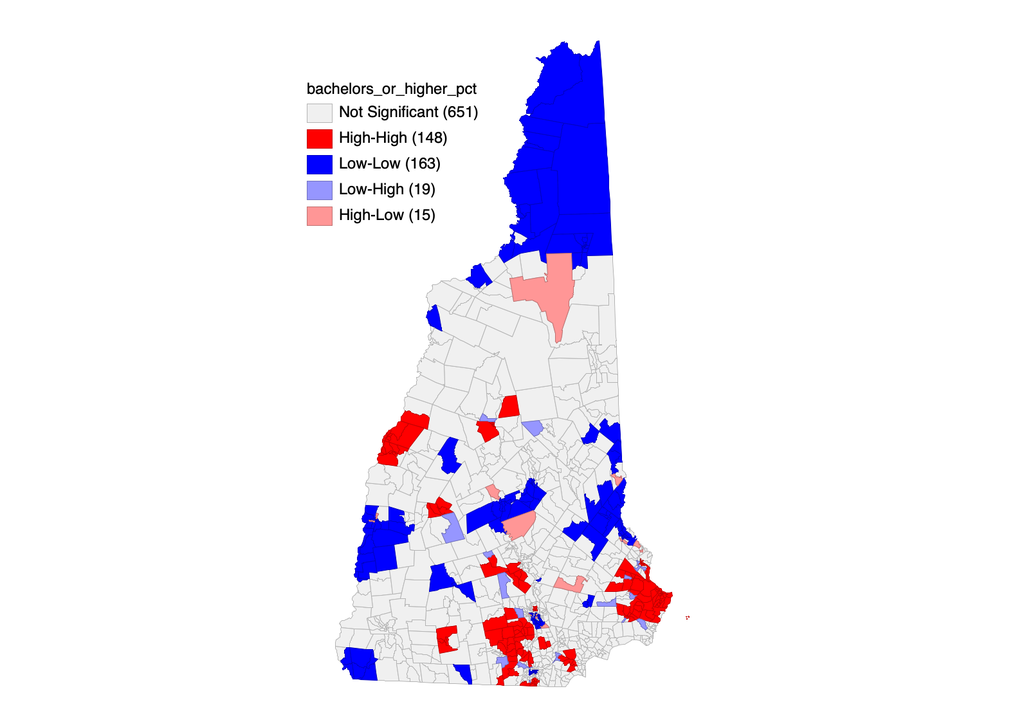

```r
knitr::include_graphics('moran_bachelor.png')
```

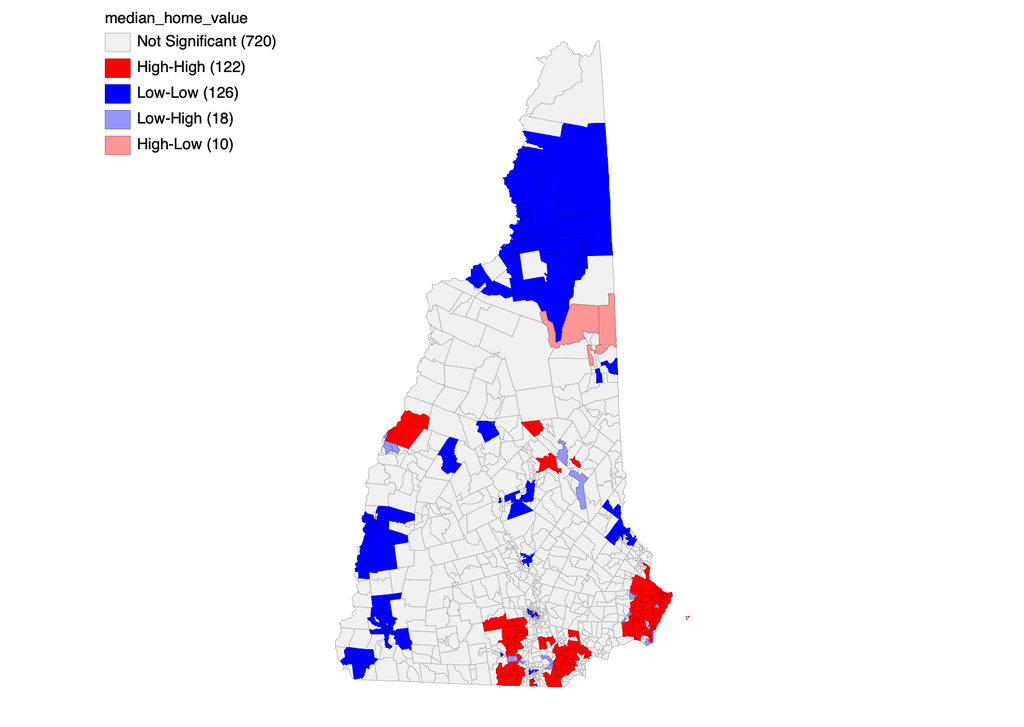

```r
knitr::include_graphics('moran_home.png')
```

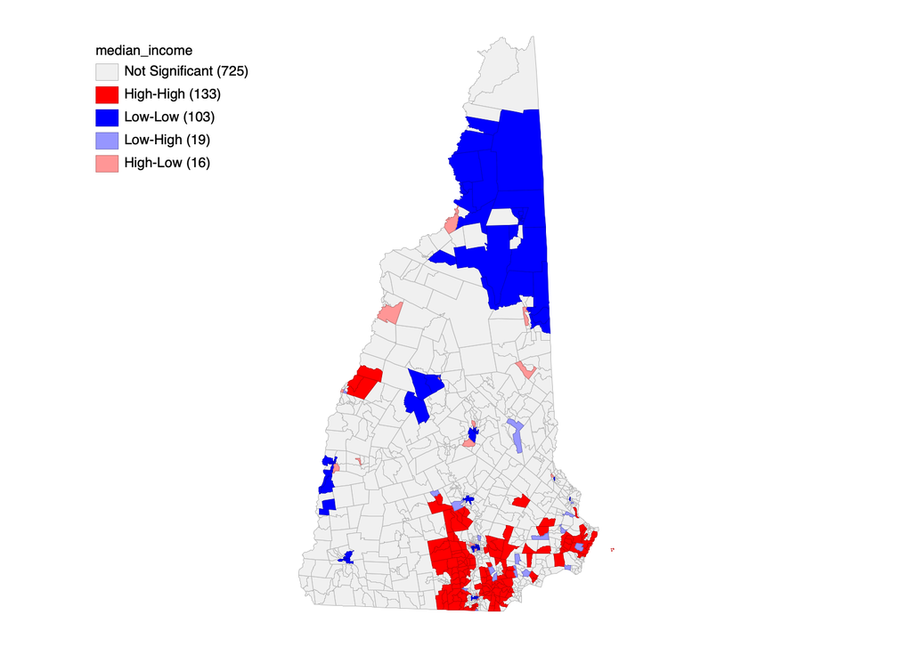

```r
knitr::include_graphics('moran_income.png')
```

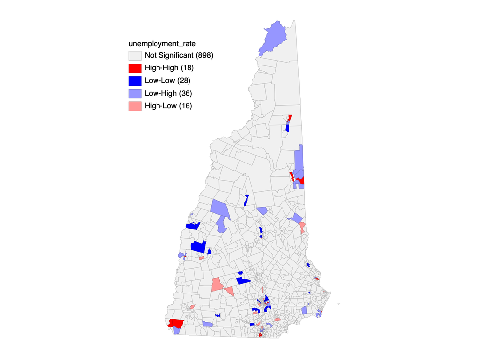

```r
knitr::include_graphics('moran_unemploy.png')
```

## Spatial Regression

To address our second research question: “whether median household income can be predicted based on distance to the nearest boarding school?”, we move from spatial autocorrelation analysis to spatial regression modeling to examine the relationship between income and distance to school.

Using GeoDa, we estimate three different regression models: 1) Ordinary Least Squares (OLS) regression, 2) Spatial Lag model, and 3) Spatial Error model.

### OLS regression

We first estimate an Ordinary Least Squares (OLS) regression of median household income on distance to the nearest boarding school.

$$\text{Income}_i = 105916 - 0.3672 \cdot \text{Distance}_i $$

The results show a statistically significant negative relationship between distance and income, with a coefficient of -0.3672. Every additional 1 ft away from the boarding school is associated with average of $0.3672 decrease in median household income. The coefficient is statistically significant.

The model has $R^2$ of 0.009563 which means that less than 1% of the variation in income across block groups. This low explanatory power suggests that other factors are likely to drive income differences.

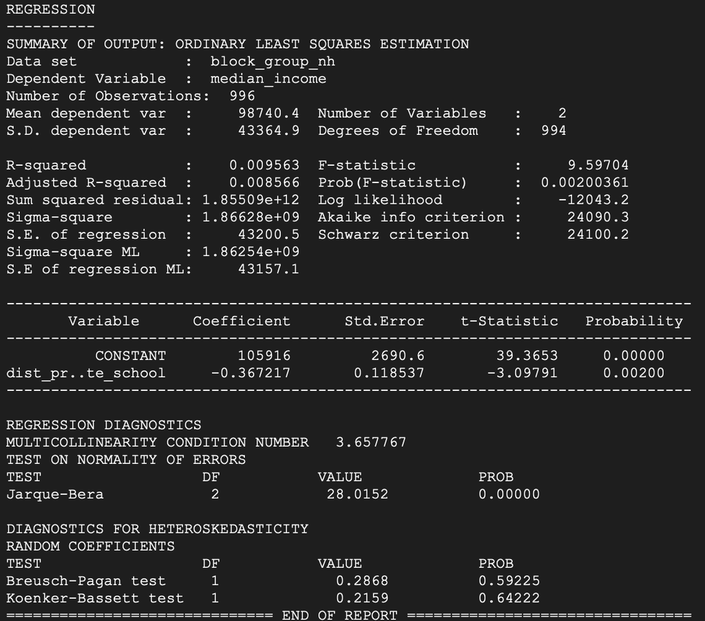

```r
knitr::include_graphics('OLS_income_dist.png')
```

When looking at the standard deviation map of residual, the residual are higher in middle to southern boundary with very high residual cluster around Manchester.

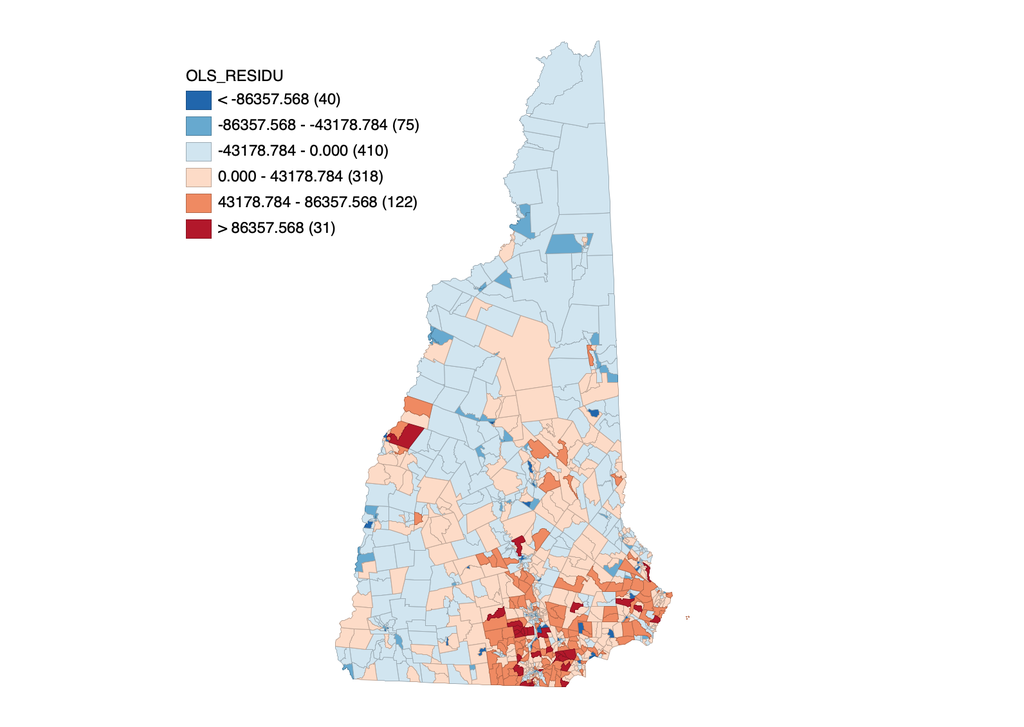

```r
knitr::include_graphics('SD_map_income.png')
```

Additionally, we see that there are clustering of High-High residuals in the southern part of the New Hampshire and Low-Low residuals around upper middle New Hampshire. They also show positive spatial autocorrelation (0.355).

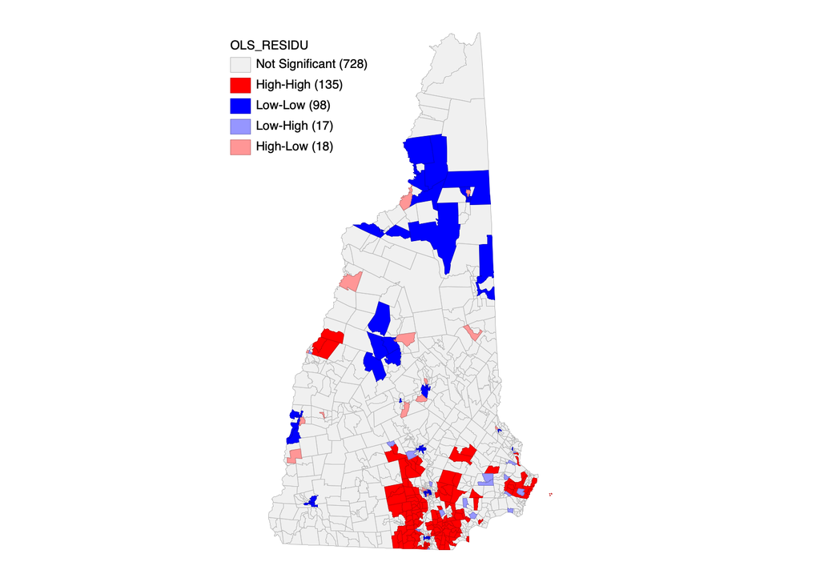

```r
knitr::include_graphics('income_residual_local_morani.png')
```

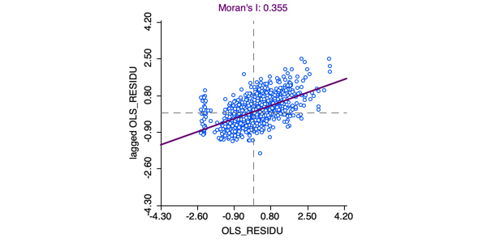

```r
knitr::include_graphics('income_residual_morani.png')
```

### Spatial Lag

Since the residuals are clustered in space, we use spatial lag model to help understand the spatial structure. The spatial lag model has $R^2$ of 0.291501 which is significantly higher than OLS regression suggesting that incoporating neighboring block group income level improve the model fit by capturing the spillover effects. The AIC score is 23837.2

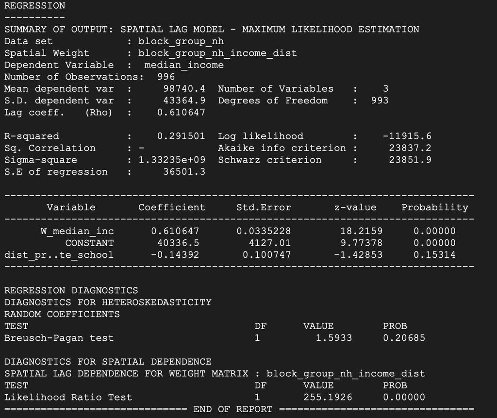

```r
knitr::include_graphics('spatial_lag_income.png')
```

### Spatial Error

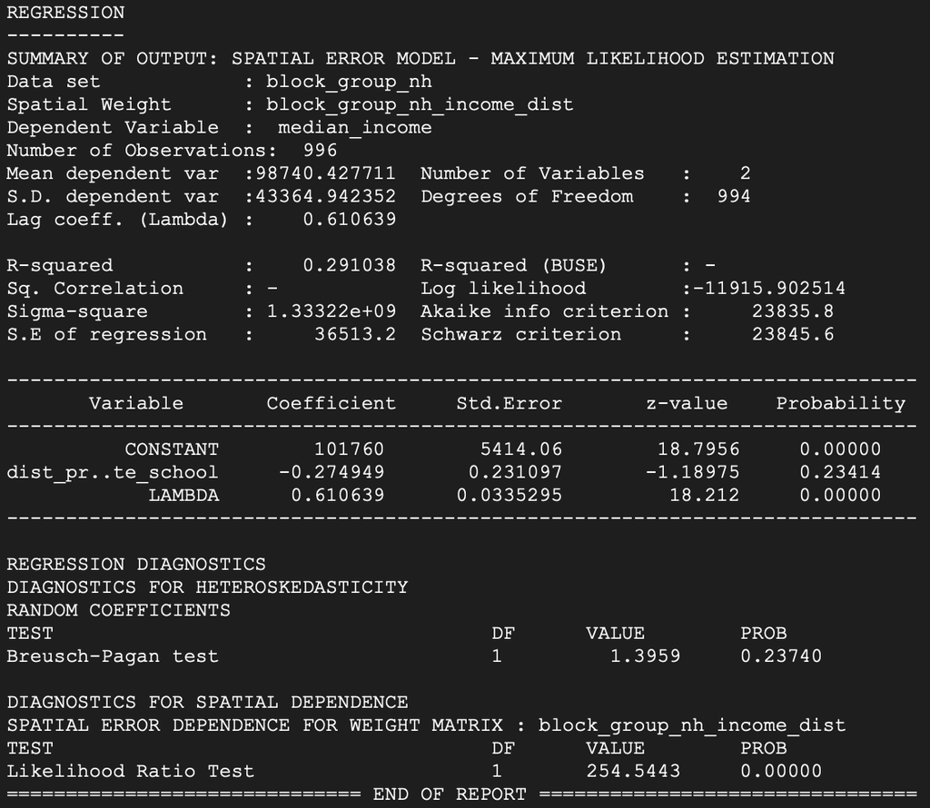

```r
knitr::include_graphics('spatial_error_income.png')
```

## Conclusion

This project investigates two research questions:

1) Whether block groups within 3 miles of boarding schools differ systematically from those outside this range.

However, spatial autocorrelation analysis reveals clear geographic clustering in the data. Variables such as median household income, home value, and educational attainment exhibit strong High-High clusters near the Massachusetts border, while Low-Low clusters are in the northern side of New Hampshire signaling the urbanization influences the disparity between areas more than boarding schools.

2) whether median household income can be predicted by distance to the nearest boarding school.

The OLS model shows a statistically significant but very weak relationship, with distance explaining less than 1% of the variation in income. To account for spatial dependence, we estimate Spatial Lag and Spatial Error models. Both models confirm strong spatial dependence in income distribution with spatial error outperforms the other suggesting that there are omitted spatial factors that driven the spatial structures that we should explore more.